# Which Events are the Most Impactful?

## Project Description

This analysis is to determine which natural events are the most impactful to humans. Impact is measured by injuries and fatalities to humans, as well as cost of damages incurred. Data is sourced from the National Weather Service, and was extracted from the Coursera Reproducible Research Peer Assessment 2 assignment page. Analysis was conducted on MAC OSX 10.11.6, with R version 3.3.0 using RStudio version 0.99.902

### First, load in the R packages required for analysis.

```r
library(ggplot2)
library(plyr)
library(dplyr)
library(R.utils)
```

## Data Processing

#### Check to see if the StormData.csv.bz2 file, which is taken from the Coursera page, exists in the working directory. If it does, skip the download. If it does not, download the file from the site.

```r
if (!file.exists("StormData.csv.bz2")) {
  tryCatch({
    download.file("https://d396qusza40orc.cloudfront.net/repdata%2Fdata%2FStormData.csv.bz2", "StormData.csv.bz2")
    print("File did not exist, but was successfully downloaded from the URL.")
  },
  error = function(cond) {
    print(
      "File did not exist, but there was an error in downloading the file from the provided URL."
    )
  })
} else {
  print("File StormData.csv.bz2 already exists")
}
```

#### Check to see if StormData.csv exists. If it does not, unzip file StormData.csv.bz2. If it does, do nothing.

```r
if (!file.exists("StormData.csv")) {
  tryCatch({
    bunzip2("StormData.csv.bz2", "StormData.csv", remove = FALSE, skip = TRUE)
    print("File did not exist, but was successfully unzipped using bunzip2.")
  },
  error = function(cond) {
    print(
      "File did not exist, but there was an error in unzipping the file from the provided URL."
    )
  })
} else {
  print("File StormData.csv already exists")
}

storm.data <- read.table("StormData.csv",na.strings=c(""),header=TRUE,fill=TRUE,row.names=NULL,quote="\"",sep=",")
```

#### Since a lot of data is missing, determine which years to remove because of bad or missing data. Do so by first creating a column with the extracted year. Then, do a row count of events by year and see if there’s any distinguishable period of time where the number of events increases. This can be used as a way to determine when the data becomes a bit cleaner.

```r
storm.data$year = as.numeric(format(as.Date(storm.data$BGN_DATE, format="%m/%d/%Y %H:%M:%S"), "%Y"))
```

```r
storm.data.byyear <- aggregate(LENGTH ~ year, data = storm.data, FUN = function(x){NROW(x)})
colnames(storm.data.byyear) <- c('Year', 'NumberOfEvents')

storm.data.byyear.sorted = storm.data.byyear[order(storm.data.byyear$Year,decreasing = TRUE),]
```

#### Now, take a look at the most recent 50 years and see if any year jumps out as being a good breaking point.

```r
head(storm.data.byyear.sorted,50)
```

```
##    Year NumberOfEvents
## 62 2011          62174
## 61 2010          48161
## 60 2009          45817
## 59 2008          55663
## 58 2007          43289
## 57 2006          44034
## 56 2005          39184
## 55 2004          39363
## 54 2003          39752
## 53 2002          36293
## 52 2001          34962
## 51 2000          34471
## 50 1999          31289
## 49 1998          38128
```

[output cut: 36 more lines]

#### The above data shows that the number increases dramatically between 1993 and 1994 To be safe, restrict data to be from 1994 - 2011

```r
storm.data.ready <- subset(storm.data, year >= 1994)
```

```r
storm.data.ready$PROP_DMG_EXP_NUM = as.character(storm.data.ready$PROPDMGEXP)

storm.data.ready$PROP_DMG_EXP_NUM[toupper(storm.data.ready$PROPDMGEXP) == ''] = "0"
storm.data.ready$PROP_DMG_EXP_NUM[toupper(storm.data.ready$PROPDMGEXP) == 'H'] = "2"
storm.data.ready$PROP_DMG_EXP_NUM[toupper(storm.data.ready$PROPDMGEXP) == 'K'] = "3"
storm.data.ready$PROP_DMG_EXP_NUM[toupper(storm.data.ready$PROPDMGEXP) == 'M'] = "6"
storm.data.ready$PROP_DMG_EXP_NUM[toupper(storm.data.ready$PROPDMGEXP) == 'B'] = "9"

storm.data.ready$PROP_DMG_EXP_NUM = as.numeric(storm.data.ready$PROPDMGEXP)
storm.data.ready$PROP_DMG_EXP_NUM[is.na(storm.data.ready$PROPDMGEXP)] = 0

storm.data.ready$DamageToProperty = storm.data.ready$PROPDMG * 10^storm.data.ready$PROP_DMG_EXP_NUM
```

```r
storm.data.ready$CROP_DMG_EXP_NUM = as.character(storm.data.ready$CROPDMGEXP)
storm.data.ready$CROP_DMG_EXP_NUM[is.na(storm.data.ready$PROPDMGEXP)] = 0

storm.data.ready$CROP_DMG_EXP_NUM[toupper(storm.data.ready$CROPDMGEXP) == ''] = "0"
storm.data.ready$CROP_DMG_EXP_NUM[toupper(storm.data.ready$CROPDMGEXP) == 'H'] = "2"
storm.data.ready$CROP_DMG_EXP_NUM[toupper(storm.data.ready$CROPDMGEXP) == 'K'] = "3"
storm.data.ready$CROP_DMG_EXP_NUM[toupper(storm.data.ready$CROPDMGEXP) == 'M'] = "6"
storm.data.ready$CROP_DMG_EXP_NUM[toupper(storm.data.ready$CROPDMGEXP) == 'B'] = "9"

storm.data.ready$CROP_DMG_EXP_NUM = as.numeric(storm.data.ready$CROPDMGEXP)
storm.data.ready$CROP_DMG_EXP_NUM[is.na(storm.data.ready$CROPDMGEXP)] = 0

storm.data.ready$DamageToCrop = storm.data.ready$CROPDMG * 10^storm.data.ready$CROP_DMG_EXP_NUM
```

#### In order to better categorize damage by event, group specifically named events together with broader terms (e.g.: HURRICANE OPAL to HURRICANE or EARLY FROST to COLD). Do this by examining column EVTYPE to get the distinct values.

```r
storm.data.ready$EVTYPE[toupper(storm.data.ready$EVTYPE) %in%
               c("HURRICANE/TYPHOON",
                 "HURRICANE OPAL",
                 "HURRICANE OPAL/HIGH WINDS",
                 "HURRICANE EMILY",
                 "TYPHOON",
                 "HURRICANE ERIN")] = "HURRICANE"

storm.data.ready$EVTYPE[toupper(storm.data.ready$EVTYPE) %in%
               c("TROPICAL STORM GORDON",
                 "TROPICAL STORM JERRY")] = "TROPICAL STORM"

storm.data.ready$EVTYPE[toupper(storm.data.ready$EVTYPE) %in%
               c("EXTREME COLD",
                 "FROST/FREEZE",
                 "FROST",
                 "EARLY FROST ",
                 "DAMAGING FREEZE",
                 "RECORD COLD",
                 "COLD/WIND CHILL",
                 "EXTREME COLD/WIND CHILL",
                 "UNSEASONABLY COLD",
                 "UNSEASONABLE COLD",
                 "HARD FREEZE",
                 "FREEZE")] = "COLD"

storm.data.ready$EVTYPE[toupper(storm.data.ready$EVTYPE) %in%
               c("EXCESSIVE HEAT",
                 "HEAT WAVE",
                 "EXTREME HEAT",
                 "UNSEASONABLY WARM",
                 "RECORD/EXCESSIVE HEAT",
                 "RECORD HEAT")] = "HEAT"

storm.data.ready$EVTYPE[toupper(storm.data.ready$EVTYPE) %in%
               c("WATERSPOUT/TORNADO"
               )] = "TORNADO"

storm.data.ready$EVTYPE[toupper(storm.data.ready$EVTYPE) %in%
               c("RIVER FLOODING"
               )] = "RIVER FLOOD"

storm.data.ready$EVTYPE[toupper(storm.data.ready$EVTYPE) %in%
               c("FLOODING",
                 "MAJOR FLOOD")] = "FLOOD"

storm.data.ready$EVTYPE[toupper(storm.data.ready$EVTYPE) %in%
               c("COASTAL FLOODING",
                 "COASTAL FLOODING/EROSION",
                 "COASTAL  FLOODING/EROSION",
                 "EROSION/CSTL FLOOD",
                 "COASTAL FLOOD")] = "COASTAL FLOOD"

storm.data.ready$EVTYPE[toupper(storm.data.ready$EVTYPE) %in%
               c("FLASH FLOODING",
                 "FLASH FLOOD/FLOOD",
                 "FLOOD/FLASH FLOOD")] = "FLASH FLOOD"

storm.data.ready$EVTYPE[toupper(storm.data.ready$EVTYPE) %in%
               c("STORM SURGE/TIDE")] = "STORM SURGE"
storm.data.ready$EVTYPE[toupper(storm.data.ready$EVTYPE) %in%
               c("WILD/FOREST FIRE",
                 "WILDFIRES",
                 "WILD FIRES")] = "WILDFIRE"

storm.data.ready$EVTYPE[toupper(storm.data.ready$EVTYPE) %in%
               c("HIGH WINDS",
                 "HIGH WIND",
                 "BLOWING WIND",
                 "STRONG WINDS",
                 "STRONG WIND",
                 "TSTM WIND",
                 "SEVERE THUNDERSTORM WINDS",
                 "THUNDERSTORM WINDS")] = "WIND"

storm.data.ready$EVTYPE[toupper(storm.data.ready$EVTYPE) %in%
               c("SMALL HAIL")] = "HAIL"
```

#### Because there are so many event types, look only at the top 100 most impactful. Define impact as Total Damage. S the data by TotalDamage, and keep only the top 100. Do the same for Property and Crop, as well. Then, panel plot the three for comparison.

###### Before building the column and display the plots, add function multiplot, which is from an R cookbook. (Linked here: http://www.cookbook-r.com/Graphs/Multiple_graphs_on_one_page_(ggplot2)/)

```r
multiplot <- function(..., plotlist=NULL, file, cols=1, layout=NULL) {
  require(grid)

  # Make a list from the ... arguments and plotlist
  plots <- c(list(...), plotlist)

  numPlots = length(plots)

  # If layout is NULL, then use 'cols' to determine layout
  if (is.null(layout)) {
    # Make the panel
    # ncol: Number of columns of plots
    # nrow: Number of rows needed, calculated from # of cols
    layout <- matrix(seq(1, cols * ceiling(numPlots/cols)),
                     ncol = cols, nrow = ceiling(numPlots/cols))
  }

  if (numPlots==1) {
    print(plots[[1]])

  } else {
    # Set up the page
    grid.newpage()
    pushViewport(viewport(layout = grid.layout(nrow(layout), ncol(layout))))

    # Make each plot, in the correct location
    for (i in 1:numPlots) {
      # Get the i,j matrix positions of the regions that contain this subplot
      matchidx <- as.data.frame(which(layout == i, arr.ind = TRUE))

      print(plots[[i]], vp = viewport(layout.pos.row = matchidx$row,
                                      layout.pos.col = matchidx$col))
    }
  }
}
```

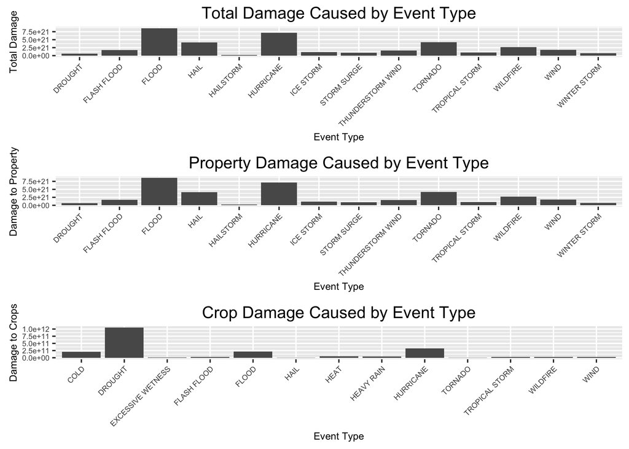

```r
storm.data.ready$TotalDamages = storm.data.ready$DamageToProperty + storm.data.ready$DamageToCrop
sorted.by.TotalDamage = storm.data.ready[order(storm.data.ready$TotalDamages,decreasing = TRUE),]
sorted.by.PropDamage = storm.data.ready[order(storm.data.ready$DamageToProperty,decreasing = TRUE),]
sorted.by.CropDamage = storm.data.ready[order(storm.data.ready$DamageToCrop,decreasing = TRUE),]
Top.100.TotalDamage <- head(sorted.by.TotalDamage,100)[,c('EVTYPE','TotalDamages')]
Top.100.PropDamage <- head(sorted.by.PropDamage,100)[,c('EVTYPE','DamageToProperty')]
Top.100.CropDamage <- head(sorted.by.CropDamage,100)[,c('EVTYPE','DamageToCrop')]

TotalDamage <- ggplot(data=Top.100.TotalDamage, aes(x=EVTYPE, y=TotalDamages)) +
  geom_bar(stat="identity") +
  labs(x="Event Type", y="Total Damage") +
  ggtitle("Total Damage Caused by Event Type") +
  theme(axis.text=element_text(size=6),axis.title=element_text(size=8),axis.text.x = element_text(angle = 45, hjust = 1))

PropDamage <- ggplot(data=Top.100.PropDamage, aes(x=EVTYPE, y=DamageToProperty)) +
  geom_bar(stat="identity") +
  labs(x="Event Type", y="Damage to Property") +
  ggtitle("Property Damage Caused by Event Type") +
  theme(axis.text=element_text(size=6),axis.title=element_text(size=8),axis.text.x = element_text(angle = 45, hjust = 1))

CropDamage <- ggplot(data=Top.100.CropDamage, aes(x=EVTYPE, y=DamageToCrop)) +
  geom_bar(stat="identity") +
  labs(x="Event Type", y="Damage to Crops") +
  ggtitle("Crop Damage Caused by Event Type") +
  theme(axis.text=element_text(size=6),axis.title=element_text(size=8),axis.text.x = element_text(angle = 45, hjust = 1))

multiplot(TotalDamage,PropDamage,CropDamage)
```

#### Another consideration for impact is effect on people. Repeat the above with data related to impact to humans. Injury counts and fatality counts are available, so aggregate and create TotalPeople. Plot the INJURIES, FATALITIES, and TotalPeople Impact by Event type.

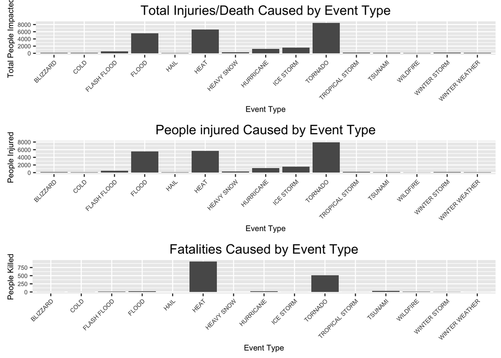

```r
storm.data.ready$TotalPeople = storm.data.ready$INJURIES + storm.data.ready$FATALITIES
sorted.by.impacted.people = storm.data.ready[order(storm.data.ready$TotalPeople,decreasing = TRUE),]
sorted.by.injury = storm.data.ready[order(storm.data.ready$INJURIES,decreasing = TRUE),]
sorted.by.fatality = storm.data.ready[order(storm.data.ready$FATALITIES,decreasing = TRUE),]
Top.100.impacted.people <- head(sorted.by.impacted.people,100)[,c('EVTYPE','TotalPeople')]
Top.100.injury <- head(sorted.by.impacted.people,100)[,c('EVTYPE','INJURIES')]
Top.100.fatality <- head(sorted.by.impacted.people,100)[,c('EVTYPE','FATALITIES')]

TotalPeople <- ggplot(data=Top.100.impacted.people, aes(x=EVTYPE, y=TotalPeople)) +
  geom_bar(stat="identity") +
  labs(x="Event Type", y="Total People Impacted") +
  ggtitle("Total Injuries/Death Caused by Event Type") +
  theme(axis.text=element_text(size=6),axis.title=element_text(size=8),axis.text.x = element_text(angle = 45, hjust = 1))

Injury <- ggplot(data=Top.100.injury, aes(x=EVTYPE, y=INJURIES)) +
  geom_bar(stat="identity") +
  labs(x="Event Type", y="People Injured") +
  ggtitle("People injured Caused by Event Type") +
  theme(axis.text=element_text(size=6),axis.title=element_text(size=8),axis.text.x = element_text(angle = 45, hjust = 1))

Fatalities <- ggplot(data=Top.100.fatality, aes(x=EVTYPE, y=FATALITIES)) +
  geom_bar(stat="identity") +
  labs(x="Event Type", y="People Killed") +
  ggtitle("Fatalities Caused by Event Type") +
  theme(axis.text=element_text(size=6),axis.title=element_text(size=8),axis.text.x = element_text(angle = 45, hjust = 1))

multiplot(TotalPeople,Injury,Fatalities)
```

## Results:

#### Flood, hurricane, hail and tornados caused the most total damage.

- Flood, hurricane, hail, and tornados caused the most property damage.
- Cold, flood, hurricane, and draught caused the most crop damage.

##### Tornados, flood and heat caused the most injuries/death.

- Tornados, flood and heat caused the most injuries
- By far, head and (in a distant second) tornados caused the most fatalities.